# R: 最低賃金の若年雇用への影響

田中 鮎夢

2024-08-11

This version: 2024-11-05

# 1 はじめに

- この資料は、Rの`did`パッケージに付属しているデータを用いて、DiD（difference-in-differences）の実装を解説するものである。
- DiDを用いて、最低賃金の引き上げが若年労働者の雇用に与える影響を検証する。
- この資料では、以下の手法を用いて、処置効果を推定する。
  1. 2元固定効果モデル（TWFE model）: `fixest`パッケージ
  2. Sun and Abraham (2021) 推定量: `fixest`パッケージ
  3. Callaway and Sant’Anna (2021) 推定量: `did`パッケージ
- この資料で必要なパッケージのインストールは以下のコードで行える。

```
install.packages(c("tidyverse", "did", "fixest", "panelView", "modelsummary", "rio"))
```

# 2 推定量

- まず、Callaway (2023) の記法に従って、ターゲット・パラメータを以下で記述する。

## 2元固定効果モデル

**静学**

- まず、共変量のない標準的な2元固定効果モデル（two way fixed effects model）の静学的な推定式は以下の通りである。

$$Y_{i t}=
\underbrace{\color{green}{\theta_{t}}}_{時間FE}+
\underbrace{\color{red}{\eta_{i}}}_{個体FE}+
\color{blue}{\alpha} \underbrace{D_{i t}}_{処置}+
v_{i t}
\qquad (1)$$

- 変数の定義
  - $Y_{it}$: アウトカム（the outcome of interest）
  - $\color{green}{θ_{t}}$: 時間固定効果（a time fixed effect）
  - $\color{red}{\eta_{i}}$: 個体固定効果（a unit fixed effect0
  - $D_{it}$: 処置ダミー（an indicator for whether or not unit i participated in the treatment in time period t）
  - $v_{it}$: 特異的な時変非観測変数（idiosyncratic, time-varying unobservables）

**動学**

- 本資料で推定するイベント・スタディ係数は、以下の動学的なイベント・スタディ回帰（event study regression）から得られる。

$$Y_{i t}=
\underbrace{\color{green}{\theta_{t}}}_{時間FE}+
\underbrace{\color{red}{\eta_{i}}}_{個体FE}+
\sum_{e=-(\mathcal{T}-1)}^{-2} \color{blue}{\beta_{e}}
\color{purple}{D_{i t}^{e}}
+
\sum_{e=0}^{\mathcal{T}-1} \color{blue}{\beta_{e}} \color{purple}{D_{i
t}^{e}}
+
v_{i t}$$

- $\color{purple}{D_{i t}^{e}}$は、ユニット$i$が期間$t$に処置を受けてから$e$期間経過しているかどうかを示すダミー変数である。

## Sun and Abraham (2021) 推定量

- Sun and Abraham (2021)は、2元固定効果モデルを拡張し、相対時間とグループ（コホート）を完全に相互作用させた推定式を用いて、グループ別平均処置効果の推定値を得る回帰ベースの方法を提案している。

$$Y_{i t}=
\underbrace{\color{green}{\theta_{t}}}_{時間FE}+
\underbrace{\color{red}{\eta_{i}}}_{個体FE}+
\sum_{g \in \overline{\mathcal{G}}}
\sum_{e \neq-1}
\color{blue}{\delta_{g e}^{S A} }
\underbrace{\mathbf{1}\left\{G_{i}=g\right\} }_{グループ}
\underbrace{\mathbf{1}\{g+e=t\}}_{相対時間}
+
v_{i t}
\qquad (7)$$

- $\color{blue}{\delta_{g e}^{S A}}$は、グループ$g$と相対時間$e$の交互作用の係数。
  - これは、グループ$g$の処置後期間$e$における平均処置効果を示す。
- Sun and Abraham (2021) は、Callaway and Sant’Anna (2021) が用いる「グループ」（group）ではなく、「コホート」（cohort）という用語を用いているが、両者の意味は同じである。

## Callaway and Sant’Anna (2021) 推定量

**Step1. グループ時間別平均処置効果**

- **共変量なし**

$$\color{green}{A T T(g, t)}=\mathbb{E}\left[Y_{t}(g)-Y_{t}(0) \mid
G=g\right]$$
ここで、$g$は、$g$時点で初めて処置を受けた処置群を示す。

- **共変量あり**

$$\color{green}{A T T(g, t)}=
\mathbb{E}\left[\left(\frac{1\{G=g\}}{p_{g}}
-
\frac{\frac{p_{g}(X) U}{p_{g}\left(1-p_{g}(X)\right)}}
{\mathbb{E}\left[\frac{p_{g}(X)
U}{p_{g}\left(1-p_{g}(X)\right)}\right]}\right)
\left(Y_{t}-Y_{g-1}-m_{g t}^{n t}(X)\right)\right]$$

- 変数の定義
  - $p_{g}(X)$は、共変量$X$を条件付けとして、$g$群に属する確率を示す。
  - $X$は、処置の選択に影響を与える共変量である。
  - $U$は、処置を受けていない比較群を表すダミー変数である。
  - $m_{g t}^{n t}(X)$は、共変量$X$を条件付けとして、比較群の処置後期間$t$における平均変化を示す。
    $$m_{g t}^{n t}(X):=\mathbb{E}\left[Y_{t}-Y_{g-1} \mid X, U=1\right]$$

**Step 2. イベント・スタディ・パラメータ**

$$\color{blue}{A T T^{E S}(e)}=\sum_{g \in \mathcal{G}} \underbrace{w^{E
S}(g, e)}_{ウェイト} \underbrace{\color{green}{A T T(g,
g+e)}}_{グループ時間別平均処置効果}$$
ここで、$e=t-g$である。

# 3 データ

## データの読み込み

```r
library(tidyverse)
library(did)
data(mpdta)
rio::export(mpdta, "mpdta.csv")
```

- このデータは、`did`パッケージに付属しているものである。Callaway and Sant’Anna (2021)によるデータセットであり、米国の最低賃金の引き上げが若年労働者の雇用に与える影響を検証するために作成されたものである。
- 人工的なデータセットである。
- Callaway and Sant’Anna (2021)論文のデータそのものは公開されておらず、このデータセットと年次が違うなど論文の結果を再現することはできない。
- 含まれている変数は以下の通りである。
- year: 年次。2003年から2007年までの5年間。
- countyreal: 郡のID
- lpop: 郡の人口 - 共変量
- lemp: 郡の若年雇用者数- アウトカム変数
- first.treat: 最初の介入の年次
- treat: 処置群ダミー

## 年次の確認

- 年次の分布を確認する。

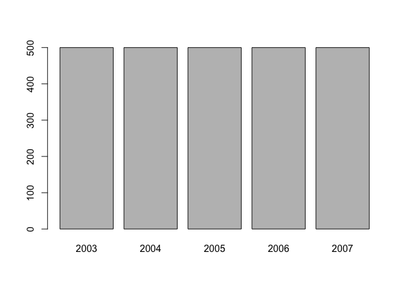

```r
barplot(table(mpdta$year))
```

- 処置年次の分布を確認する。
- `first.treat`は、最初の介入の年次を示す変数である。0は、処置がないことを示す。

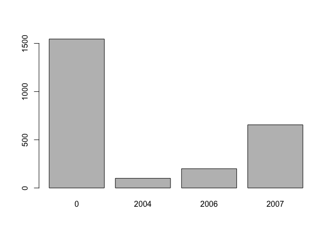

```r
barplot(table(mpdta$first.treat))
```

## 記述統計

- `modelsummary`パッケージの`datasummary`で記述統計の確認を行う。

```r
# `modelsummary`で記述統計の確認を行う。
modelsummary::datasummary(
                            year + countyreal +
                            lpop + lemp + treat
                          + first.treat
                          ~ (mean + sd + min + max + length),
                          data = mpdta)
```

|  | mean | sd | min | max | length |
| --- | --- | --- | --- | --- | --- |
| year | 2005.00 | 1.41 | 2003.00 | 2007.00 | 2500.00 |
| countyreal | 32211.04 | 13736.02 | 8001.00 | 55137.00 | 2500.00 |
| lpop | 3.31 | 1.28 | 0.07 | 7.70 | 2500.00 |
| lemp | 5.77 | 1.51 | 1.10 | 10.44 | 2500.00 |
| treat | 0.38 | 0.49 | 0.00 | 1.00 | 2500.00 |
| first.treat | 766.47 | 975.10 | 0.00 | 2007.00 | 2500.00 |

```r
# 比較群 versus 処置群
modelsummary::datasummary_balance(~treat,
                          data = mpdta)
```

|  | 0 Mean | 0 Std. Dev. | 1 Mean | 1 Std. Dev. |
| --- | --- | --- | --- | --- |
| year | 2005.0 | 1.4 | 2005.0 | 1.4 |
| countyreal | 33573.4 | 14383.2 | 30007.1 | 12310.8 |
| lpop | 3.2 | 1.3 | 3.5 | 1.2 |
| lemp | 5.6 | 1.5 | 6.0 | 1.5 |
| first.treat | 0.0 | 0.0 | 2006.5 | 0.9 |

## 処置状態の推移 with `panelView`

- `panelView`パッケージで処置状態の推移を可視化する。パッケージ名では、`V`は大文字だが、関数名では、`v`は小文字であることに注意が必要である。

```r
# 時変処置状態ダミー
mpdta$treatit <- ifelse(mpdta$year >= mpdta$first.treat, 1, 0)

# `panelView`でデータを確認する。
panelView::panelview(1 ~ treatit ,
                     data = as.data.frame(mpdta),
                     by.timing = TRUE,
                     background = "white",
                     color = c("grey","pink"),
                     index = c("countyreal", "year")
                     )
```

```
## Specified colors in the order of: Under Control, Under Treatment.
```

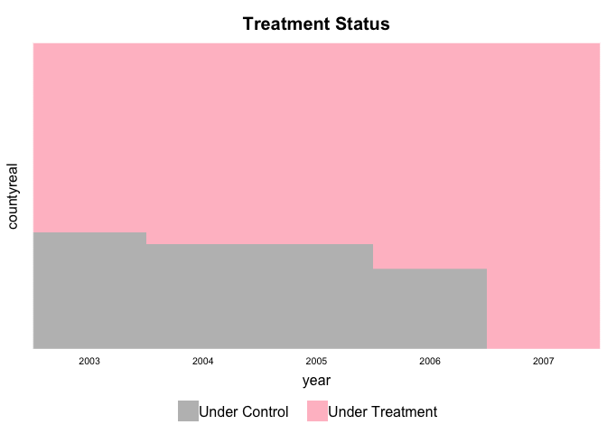

## 相対時間の作成

- TWFEとSun and Abraham (2021)の推定に必要なevent timeを作成する。

```r
# event timeを作成する。
mpdta$event_time = mpdta$year - mpdta$first.treat
mpdta$event_time[mpdta$treat==0] = 10000
```

# 4 TWFE with `fixest` package

2元固定効果モデル（TWFE model）で推定を行う。

- ここで、`i(event_time, ref = c(-1, 10000))` 構文を用いて、相対時間変数`event_time`を指定している。
  - また、基準となる`ref`に処置前年(-1)とnever-treated (10000)を指定している。
- `lemp`は、アウトカム変数（各郡の若年雇用）である。
- `| countyreal + year` は、郡固定効果と年次ダミーを指定している。

```r
# TWFEモデルに基づいて、ATTを推定する。
twfe = fixest::feols(lemp ~
              i(event_time, ref = c(-1, 10000))
              | countyreal + year,
              data = mpdta)

fixest::etable(twfe)
```

```
##                                twfe
## Dependent Var.:                lemp
##
## event_time = -4     0.0035 (0.0228)
## event_time = -3     0.0246 (0.0177)
## event_time = -2    0.0233. (0.0134)
## event_time = 0    -0.0181. (0.0110)
## event_time = 1    -0.0435* (0.0176)
## event_time = 2  -0.1318*** (0.0288)
## event_time = 3   -0.0922** (0.0323)
## Fixed-Effects:  -------------------
## countyreal                      Yes
## year                            Yes
## _______________ ___________________
## S.E.: Clustered      by: countyreal
## Observations                  2,500
## R2                          0.99326
## Within R2                   0.01034
## ---
## Signif. codes: 0 '***' 0.001 '**' 0.01 '*' 0.05 '.' 0.1 ' ' 1
```

## イベント・スタディ・プロット

- イベント・スタディ・プロットを作成する。

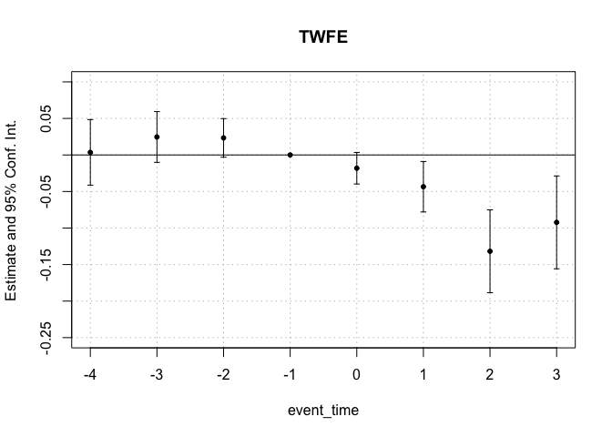

```r
# イベント・スタディ・プロットを作成する。
fixest::iplot(twfe,
              ylim = c(-0.25, 0.1),
              main = "TWFE")
```

# 5 Sun and Abraham (2021) with `fixest` package

## ATT

- Sun and Abraham (2021)に基づいて、`fixest`パッケージの**sunab** 関数を使用して、相対時間ごとのATTを推定する。
- `lemp`は、アウトカム変数（各郡の若年雇用）である。
- `sunab(first.treat, event_time)` は、処置タイミング`first.treat`と相対時間`event_time`を指定している。
- `| countyreal + year` は、郡固定効果と年次ダミーを指定している。

```r
# Sun and Abraham (2021)に基づいて、ATTを推定する。
sa = fixest::feols(lemp ~
              sunab(first.treat, event_time)
              | countyreal + year,
              data = mpdta)

fixest::etable(sa)
```

[output not shown]

## イベント・スタディ・プロット

- `fixest`パッケージの**iplot**を利用して、イベント・スタディ・プロットを作成する。

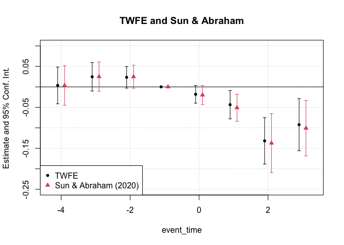

```r
# イベント・スタディ・プロットを作成する。
fixest::iplot(list(twfe, sa),
              ylim = c(-0.25, 0.1),
              main = "TWFE and Sun & Abraham")
# 凡例追加
legend("bottomleft",
                     col = c("1", "2"),
                     pch = c(20, 17),
                     legend = c("TWFE",
                                "Sun & Abraham (2020)")
              )
```

# 6 Callaway and Sant’Anna (2021) with `did` package

## 6.1 共変量なし

### グループ・時間平均処置効果

- Callaway and Sant’Anna (2021)に基づいて、**att_gt** 関数を使用して、グループ・時間平均処置効果（group-time average treatment effects）を推定する。
- TWFEやSun and Abraham (2021) は、全期間、$r=-1$をベースラインとして処置効果を推定する。
- Callaway and Sant’Anna (2021)推定量（R `did`; Stata `csdid`）は、デフォルトでは、プレ期間は$r$と$r+1$の短期差分（short difference）の比較で係数を推定する。ポスト期間は$r=-1$をベースラインとする。プレ期間とポスト期間で、基準年が変わってしまうため、プレの係数とポストの係数の単純な比較は誤解を招く。
- Roth (2024)に従って、CS推定量についても、R `did`では、`base_period = "universal"`を指定することで、プレ期間もポスト期間も$r=-1$を基準とする長期差分（long difference）を用いた比較が得られる。Stata `csdid`では、`long2`オプションにより、全期間$r=-1$をベースラインにできる。 。

```r
# Callaway and Sant'Anna (2021)に基づいて、ATTを推定する。
cs <- did::att_gt(yname = "lemp", # 結果変数
              gname = "first.treat", # 処置タイミング
              idname = "countyreal", # ユニットID
              tname = "year", # 時間変数
              xformla = ~1, # モデル
              bstrap = TRUE, # ブートストラップSEを計算
              biters = 1000, # ブートストラップの反復回数
              base_period = "universal", # ベースライン期間
              data = mpdta, # データ
              est_method = "reg", # or "dr" (doubly robust)
              control_group = "nevertreated"  # or "notyettreated"
              )

summary(cs)
```

```
##
## Call:
## did::att_gt(yname = "lemp", tname = "year", idname = "countyreal",
##     gname = "first.treat", xformla = ~1, data = mpdta, control_group = "nevertreated",
##     bstrap = TRUE, biters = 1000, est_method = "reg", base_period = "universal")
##
## Reference: Callaway, Brantly and Pedro H.C. Sant'Anna.  "Difference-in-Differences with Multiple Time Periods." Journal of Econometrics, Vol. 225, No. 2, pp. 200-230, 2021. <https://doi.org/10.1016/j.jeconom.2020.12.001>, <https://arxiv.org/abs/1803.09015>
##
## Group-Time Average Treatment Effects:
##  Group Time ATT(g,t) Std. Error [95% Simult.  Conf. Band]
##   2004 2003   0.0000         NA            NA          NA
##   2004 2004  -0.0105     0.0246       -0.0771      0.0561
##   2004 2005  -0.0704     0.0316       -0.1563      0.0154
##   2004 2006  -0.1373     0.0408       -0.2480     -0.0265 *
##   2004 2007  -0.1008     0.0350       -0.1957     -0.0059 *
##   2006 2003  -0.0038     0.0320       -0.0905      0.0830
##   2006 2004   0.0028     0.0198       -0.0510      0.0565
##   2006 2005   0.0000         NA            NA          NA
##   2006 2006  -0.0046     0.0175       -0.0520      0.0428
##   2006 2007  -0.0412     0.0194       -0.0938      0.0113
##   2007 2003   0.0033     0.0238       -0.0611      0.0678
##   2007 2004   0.0338     0.0212       -0.0237      0.0913
##   2007 2005   0.0311     0.0165       -0.0138      0.0760
##   2007 2006   0.0000         NA            NA          NA
##   2007 2007  -0.0261     0.0169       -0.0720      0.0199
## ---
## Signif. codes: `*' confidence band does not cover 0
##
## P-value for pre-test of parallel trends assumption:  0.16812
## Control Group:  Never Treated,  Anticipation Periods:  0
## Estimation Method:  Outcome Regression
```

### イベント・スタディ・プロット

- イベント・スタディ・プロットを作成するため、**aggte**関数を使用して、相対時間ごとのATTを計算する。

```r
cses <- did::aggte(cs, type = "dynamic")

# cses[["att.egt"]]、cses[["att.egt"]]、cses[["se.egt"]]を表示
summary(cses)
```

```
##
## Call:
## did::aggte(MP = cs, type = "dynamic")
##
## Reference: Callaway, Brantly and Pedro H.C. Sant'Anna.  "Difference-in-Differences with Multiple Time Periods." Journal of Econometrics, Vol. 225, No. 2, pp. 200-230, 2021. <https://doi.org/10.1016/j.jeconom.2020.12.001>, <https://arxiv.org/abs/1803.09015>
##
##
## Overall summary of ATT's based on event-study/dynamic aggregation:
##      ATT    Std. Error     [ 95%  Conf. Int.]
##  -0.0772        0.0216    -0.1195      -0.035 *
##
##
## Dynamic Effects:
##  Event time Estimate Std. Error [95% Simult.  Conf. Band]
##          -4   0.0033     0.0246       -0.0571      0.0637
##          -3   0.0250     0.0177       -0.0184      0.0684
##          -2   0.0245     0.0149       -0.0123      0.0612
##          -1   0.0000         NA            NA          NA
##           0  -0.0199     0.0117       -0.0486      0.0087
##           1  -0.0510     0.0178       -0.0948     -0.0071 *
##           2  -0.1373     0.0404       -0.2365     -0.0381 *
##           3  -0.1008     0.0342       -0.1850     -0.0166 *
## ---
## Signif. codes: `*' confidence band does not cover 0
##
## Control Group:  Never Treated,  Anticipation Periods:  0
## Estimation Method:  Outcome Regression
```

- イベントスタディをプロットするには、**ggdid**を使用する

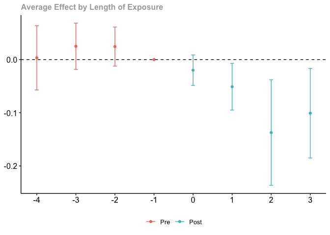

```r
# イベントスタディプロットを作成する。
did::ggdid(cses)
```

## 6.2 共変量あり

### グループ・時間平均処置効果

- `xformla = ~ lpop`として、共変量を追加する。
- `est_method = "dr"`として、doubly robust推定を行う。

```r
# Callaway and Sant'Anna (2021)に基づいて、ATTを推定する。
cs2 <- did::att_gt(yname = "lemp", # 結果変数
              gname = "first.treat", # 処置タイミング
              idname = "countyreal", # ユニットID
              tname = "year", # 時間変数
              xformla = ~ lpop, # モデル
              bstrap = TRUE, # ブートストラップSEを計算
              biters = 1000, # ブートストラップの反復回数
              base_period = "universal", # ベースライン期間
              data = mpdta, # データ
              est_method = "dr", # or "reg" (doubly robust)
              control_group = "nevertreated" # or "notyettreated"
              )

summary(cs2)
```

```
##
## Call:
## did::att_gt(yname = "lemp", tname = "year", idname = "countyreal",
##     gname = "first.treat", xformla = ~lpop, data = mpdta, control_group = "nevertreated",
##     bstrap = TRUE, biters = 1000, est_method = "dr", base_period = "universal")
##
## Reference: Callaway, Brantly and Pedro H.C. Sant'Anna.  "Difference-in-Differences with Multiple Time Periods." Journal of Econometrics, Vol. 225, No. 2, pp. 200-230, 2021. <https://doi.org/10.1016/j.jeconom.2020.12.001>, <https://arxiv.org/abs/1803.09015>
##
## Group-Time Average Treatment Effects:
##  Group Time ATT(g,t) Std. Error [95% Simult.  Conf. Band]
##   2004 2003   0.0000         NA            NA          NA
##   2004 2004  -0.0145     0.0229       -0.0742      0.0451
##   2004 2005  -0.0764     0.0307       -0.1562      0.0033
##   2004 2006  -0.1404     0.0375       -0.2379     -0.0430 *
##   2004 2007  -0.1069     0.0332       -0.1932     -0.0206 *
##   2006 2003   0.0067     0.0306       -0.0729      0.0862
##   2006 2004   0.0062     0.0194       -0.0442      0.0566
##   2006 2005   0.0000         NA            NA          NA
##   2006 2006   0.0010     0.0196       -0.0501      0.0520
##   2006 2007  -0.0413     0.0198       -0.0927      0.0101
##   2007 2003   0.0063     0.0245       -0.0574      0.0700
##   2007 2004   0.0330     0.0210       -0.0215      0.0876
##   2007 2005   0.0284     0.0175       -0.0171      0.0740
##   2007 2006   0.0000         NA            NA          NA
##   2007 2007  -0.0288     0.0161       -0.0707      0.0131
## ---
## Signif. codes: `*' confidence band does not cover 0
##
## P-value for pre-test of parallel trends assumption:  0.23267
## Control Group:  Never Treated,  Anticipation Periods:  0
## Estimation Method:  Doubly Robust
```

### イベント・スタディ・プロット

```r
cses2 <- did::aggte(cs2, type = "dynamic")

summary(cses2)
```

```
##
## Call:
## did::aggte(MP = cs2, type = "dynamic")
##
## Reference: Callaway, Brantly and Pedro H.C. Sant'Anna.  "Difference-in-Differences with Multiple Time Periods." Journal of Econometrics, Vol. 225, No. 2, pp. 200-230, 2021. <https://doi.org/10.1016/j.jeconom.2020.12.001>, <https://arxiv.org/abs/1803.09015>
##
##
## Overall summary of ATT's based on event-study/dynamic aggregation:
##      ATT    Std. Error     [ 95%  Conf. Int.]
##  -0.0804        0.0189    -0.1174     -0.0433 *
##
##
## Dynamic Effects:
##  Event time Estimate Std. Error [95% Simult.  Conf. Band]
##          -4   0.0063     0.0247       -0.0536      0.0661
##          -3   0.0269     0.0175       -0.0155      0.0692
##          -2   0.0232     0.0154       -0.0139      0.0604
##          -1   0.0000         NA            NA          NA
##           0  -0.0211     0.0114       -0.0487      0.0066
##           1  -0.0530     0.0165       -0.0928     -0.0132 *
##           2  -0.1404     0.0380       -0.2323     -0.0486 *
##           3  -0.1069     0.0360       -0.1940     -0.0198 *
## ---
## Signif. codes: `*' confidence band does not cover 0
##
## Control Group:  Never Treated,  Anticipation Periods:  0
## Estimation Method:  Doubly Robust
```

- イベントスタディをプロットするには、**ggdid**を使用する

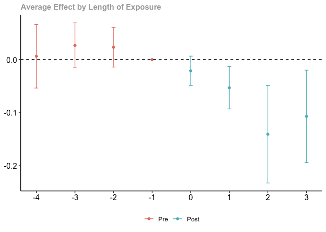

```r
did::ggdid(cses2)
```

# 参考文献

- Callaway, B. (2023). Difference-in-differences for policy evaluation. Handbook of Labor, Human Resources and Population Economics, 1-61. https://doi.org/10.1007/978-3-319-57365-6_352-1 https://doi.org/10.48550/arXiv.2203.15646
- Callaway, B., & Sant’Anna, P. H. (2021). Difference-in-differences with multiple time periods. Journal of Econometrics, 225(2), 200-230.https://doi.org/10.1016/j.jeconom.2020.12.001
- Roth, J. (2024). Interpreting event-studies from recent difference-in-differences methods. arXiv preprint arXiv:2401.12309.https://doi.org/10.48550/arXiv.2401.12309
- Sun, L., & Abraham, S. (2021). Estimating dynamic treatment effects in event studies with heterogeneous treatment effects. Journal of Econometrics, 225(2), 175-199.https://doi.org/10.1016/j.jeconom.2020.09.006

# 補論：分析環境について

- `renv`パッケージを使用して、プロジェクトごとにパッケージのバージョン情報を保存することができる。

```r
# 現時点での分析環境を保存
renv::init()

# renv.lockファイルとrenvフォルダー更新
renv::snapshot()
```

```
## - The lockfile is already up to date.
```

- この資料で使用したRとパッケージのバージョン情報は下記の通りである。バージョンの異なる場合、結果が異なったり、エラーがでる可能性がある。

```r
# パッケージのバージョン確認: tidyverse, did, fixest, panelView, modelsummary, rio
packageVersion("tidyverse")
```

```
## [1] '2.0.0'
```

```r
packageVersion("did")
```

```
## [1] '2.1.2'
```

```r
packageVersion("fixest")
```

```
## [1] '0.12.1'
```

```r
packageVersion("panelView")
```

```
## [1] '1.1.18'
```

```r
packageVersion("modelsummary")
```

```
## [1] '1.4.3'
```

```r
packageVersion("rio")
```

```
## [1] '1.2.3'
```